# Exploratory analyis and machine learning model for predicting housing prices with R (data.table and h2o.ai)

Bart Boerman

2018-01-15

# 1 Introduction

## 1.1 Version

**Raw inital version**.

## 1.2 Goal

Exploratory analyis and machine learning modal for predicting housing prices in competition [“House Prices: Advanced Regression Techniques”](https://www.kaggle.com/c/house-prices-advanced-regression-techniques). The aim is to predict house prices based on the provided data:

- **train.csv**,data for training our model
- **test.csv**, data used to see how well our model performs on unseen data

In addition I want to gain and share some basic knowledge of

- data wrangling and analysis with data.table
- machine learning with h2o
- stacking with h2o

## 1.3 Required libraries

```r
require(knitr)      ## dynamic report generation in R
knitr::opts_chunk$set(error=FALSE, message=FALSE, warning=FALSE) ## some defaults for this report
require(DT)         ## display data in html tables
require(ggplot2)    ## plotting
require(gridExtra)  ## Arrange visualizations using grid
require(data.table) ## fast data wrangling and analysis
require(psych)      ## descriptive statistics, skewness and kurtosis
require(caret)      ## (near) zero variance, dummy variables
require(h2o)        ## machine learning algorithmes and more from h2o.ai
```

# 2 Get data into R

```r
train.dt <- fread(input = "train.csv",
                  sep = ",",
                  nrows = -1,
                  header = T,
                  na.strings=c("NA","N/A","null"),
                  stringsAsFactors = F,
                  check.names = T,
                  strip.white = T,
                  blank.lines.skip = T,
                  data.table = T
)
test.dt <- fread(input = "test.csv",
                 sep = ",",
                 nrows = -1,
                 header = T,
                 na.strings=c("NA","N/A","null"),
                 stringsAsFactors = F,
                 check.names = T,
                 strip.white = T,
                 blank.lines.skip = T,
                 data.table = T
)
## Create one data set for feature engineering.
train.dt[, dataPartition:="train"]
test.dt[, SalePrice:=as.integer(NA)]
test.dt[, dataPartition:="test"]
full.dt <- rbindlist(list(train.dt, test.dt), use.names = F, fill = F) ## combine datasets for engineering
```

# 3 Data dictionary

## 3.1 Definitions

```r
## Numeric, square footage
variablesSquareFootage <- c(
  "LotFrontage",        ## Linear feet of street connected to property
  "LotArea",            ## Lot size in square feet
  "MasVnrArea",         ## Masonry veneer area in square feet
  "BsmtFinSF1",       ## Type 1 finished square feet
  "BsmtFinSF2",       ## Type 2 finished square feet
  "BsmtUnfSF",        ## Unfinished square feet of basement area
  "TotalBsmtSF",        ## Total square feet of basement area
  "FirstFlrSF",       ## First Floor square feet
  "SecondFlrSF",      ## Second floor square feet
  "LowQualFinSF",   ## Low quality finished square feet (all floors)
  "GrLivArea",        ## Above grade (ground) living area square feet
  "GarageArea",     ## Size of garage in square feet
  "WoodDeckSF",     ## Wood deck area in square feet
  "OpenPorchSF",    ## Open porch area in square feet
  "EnclosedPorch",  ## Enclosed porch area in square feet
  "ThreeSsnPorch",  ## Three season porch area in square feet
  "ScreenPorch",    ## Screen porch area in square feet
  "PoolArea"            ## Pool area in square feet
)
## Counts, a house has n of something
variablesCounts <- c(
  "BsmtFullBath",       ## Basement full bathrooms
  "BsmtHalfBath",       ## Basement half bathrooms
  "FullBath",             ## Full bathrooms above grade
  "HalfBath",             ## Half baths above grade
  "BedroomAbvGr",       ## Bedrooms above grade (does NOT include basement bedrooms)
  "KitchenAbvGr",       ## Kitchens above grade
  "TotRmsAbvGrd",       ## Total rooms above grade (does not include bathrooms)
  "Fireplaces",       ## Number of fireplaces
  "GarageCars"      ## Size of garage in car capacity
)
## Values
variablesValues <- c(
  "MiscVal",        ## $ Value of miscellaneous feature
  "SalePrice"       ## $ Price paid
)
## Factors
variablesFactor <- colnames(full.dt)[which(as.vector(full.dt[,sapply(full.dt, class)]) == "character")]
variablesFactor <- c(variablesFactor,
                     "MSSubClass",     ## Identifies the type of dwelling involved in the sale
                     "OverallQual",    ## Rates the overall material and finish of the house
                     "OverallCond",    ## Rates the overall condition of the house
                     #"MoSold",
                     "YrSold"          ## Year sold as an factor.
                     #"YearRemodAdd"
                     #"YearBuilt",
                     #"GarageYrBlt"
)
```

## 3.2 Data engineering

Before further data exploration we need to engineer the data to the desired format. Doing so we make sure that the data types are correct and hierarchical factors are sorted in the right order. The code blocks below performs the following tasks: rename variable names, change data type to numeric or factor and order hierarchical factors.

### 3.2.1 Rename variables

```r
## In R first character can not be a number in variable names
setnames(full.dt, c("X1stFlrSF","X2ndFlrSF","X3SsnPorch"), c("FirstFlrSF","SecondFlrSF","ThreeSsnPorch"))
```

### 3.2.2 Change data type

```r
## Set columns to numeric
changeColType <- c(variablesSquareFootage, variablesCounts, variablesValues)
full.dt[,(changeColType):= lapply(.SD, as.numeric), .SDcols = changeColType]
## Set columns to factor
changeColType <- variablesFactor
full.dt[,(changeColType):= lapply(.SD, as.factor), .SDcols = changeColType]
```

### 3.2.3 Order hierarchical factors

```r
## OverallQual, rates the overall material and finish of the house
full.dt[,OverallQual:=ordered(OverallQual, levels = c(1:10))]
## OverallCond, rates the overall condition of the house
full.dt[,OverallCond:=ordered(OverallCond, levels = c(1:10))]
## KitchenQual, kitchen quality
full.dt[,KitchenQual:=ordered(KitchenQual, levels = c("Po","Fa","TA","Gd","Ex"))]
## GarageFinish (contains NA's)
full.dt[,GarageFinish:=ordered(GarageFinish, levels = c("None","Unf","RFn","Fin"))]
## ExterQual, evaluates the quality of the material on the exterior
full.dt[,ExterQual:=ordered(ExterQual, levels = c("Po","Fa","TA","Gd","Ex"))]
## ExterCond, evaluates the present condition of the material on the exterior
full.dt[,ExterCond:=ordered(ExterCond, levels = c("Po","Fa","TA","Gd","Ex"))]
## BsmtQual (contains NA's), evaluates the height of the basement
full.dt[,BsmtQual:=ordered(BsmtQual, levels = c("None","Po","Fa","TA","Gd","Ex"))]
## BsmtCond (contains NA's), evaluates the general condition of the basement
full.dt[,BsmtCond:=ordered(BsmtCond, levels = c("None","Po","Fa","TA","Gd","Ex"))]
## BsmtExposure (contains NA's), refers to walkout or garden level walls
full.dt[,BsmtExposure:=ordered(BsmtExposure, levels = c("None","No","Mn","Av","Gd"))]
## BsmtFinType1 (contains NA's), rating of basement finished area
full.dt[,BsmtFinType1:=ordered(BsmtFinType1, levels = c("None","Unf","LwQ","Rec","BLQ","ALQ","GLQ"))]
## FireplaceQu (contains NA's), fireplace quality
full.dt[,FireplaceQu:=ordered(FireplaceQu, levels = c("None","Po","Fa","TA","Gd","Ex"))]
## Electrical
full.dt[,Electrical:=ordered(Electrical, levels = c("FuseP","Mix","FuseF","FuseA","SBrkr"))]
## Fence
full.dt[,Fence:=ordered(Fence, levels = c("None","MnWw","MnPrv","GdWo","GdPrv"))]
## PoolQC
full.dt[,FireplaceQu:=ordered(FireplaceQu, levels = c("None","Fa","Gd","Ex"))]
## Ordered factors are not supported by h2o, Let's convert them into integers during pre-processing. Lowest level will be 1 etc.
```

# 4 Descriptive statistics

Descriptive statistics describe quantitatively the basic features of the data. These statistics will give us a head start by providing information about for example skewness, outliers (range) missing data points and (near) zero variance.

## 4.1 Table with basic statistics

The table below is calculated with the psych package.

```r
descStats.df <- describe(full.dt[, c(variablesSquareFootage,variablesValues), with = FALSE])
datatable(round(descStats.df,2), rownames = T,
          caption = "Descriptive statistics",
          options = list(pageLength = 8)) ## Interactive HTML table
```

|  | vars | n | mean | sd | median | trimmed | mad | min | max | range | skew | kurtosis | se |
| --- | --- | --- | --- | --- | --- | --- | --- | --- | --- | --- | --- | --- | --- |
| LotFrontage | 1 | 2433 | 69.31 | 23.34 | 68 | 68.44 | 17.79 | 21 | 313 | 292 | 1.5 | 11.26 | 0.47 |
| LotArea | 2 | 2919 | 10168.11 | 7887 | 9453 | 9499.49 | 3023.02 | 1300 | 215245 | 213945 | 12.82 | 264.31 | 145.98 |
| MasVnrArea | 3 | 2896 | 102.2 | 179.33 | 0 | 61.41 | 0 | 0 | 1600 | 1600 | 2.6 | 9.23 | 3.33 |
| BsmtFinSF1 | 4 | 2918 | 441.42 | 455.61 | 368.5 | 382.44 | 546.34 | 0 | 5644 | 5644 | 1.42 | 6.88 | 8.43 |
| BsmtFinSF2 | 5 | 2918 | 49.58 | 169.21 | 0 | 1.9 | 0 | 0 | 1526 | 1526 | 4.14 | 18.79 | 3.13 |
| BsmtUnfSF | 6 | 2918 | 560.77 | 439.54 | 467 | 512.46 | 415.13 | 0 | 2336 | 2336 | 0.92 | 0.4 | 8.14 |
| TotalBsmtSF | 7 | 2918 | 1051.78 | 440.77 | 989.5 | 1034.98 | 350.63 | 0 | 6110 | 6110 | 1.16 | 9.13 | 8.16 |
| FirstFlrSF | 8 | 2919 | 1159.58 | 392.36 | 1082 | 1127.14 | 348.41 | 334 | 5095 | 4761 | 1.47 | 6.94 | 7.26 |
| SecondFlrSF | 9 | 2919 | 336.48 | 428.7 | 0 | 274.21 | 0 | 0 | 2065 | 2065 | 0.86 | -0.43 | 7.93 |
| LowQualFinSF | 10 | 2919 | 4.69 | 46.4 | 0 | 0 | 0 | 0 | 1064 | 1064 | 12.08 | 174.51 | 0.86 |

[output cut: 10 more lines]

## 4.2 Table with counts on missing values

The table below provides counts on unknown (a.k.a. missing) values per variable. Please not that missing values are often legitimate. For example when a dwelling does not have a garage no value is provided in the corresponding variables. We will impute them with “None” or a zero further down this analysis.

```r
countIsNA <- sapply(full.dt,function(x)sum(is.na(x)))
countIsNA.df <- data.frame(countIsNA)
countIsNA.df <- data.frame(variableName = row.names(countIsNA.df), countIsNA.df,row.names = NULL)
countIsNA.df <- countIsNA.df[countIsNA >0,]
datatable(countIsNA.df, rownames = T,
          caption = "Variables with missing values",
          options = list(pageLength = 8))
```

|  | variableName | countIsNA |
| --- | --- | --- |
| 3 | MSZoning | 4 |
| 4 | LotFrontage | 486 |
| 7 | Alley | 2721 |
| 10 | Utilities | 2 |
| 24 | Exterior1st | 1 |
| 25 | Exterior2nd | 1 |
| 26 | MasVnrType | 24 |
| 27 | MasVnrArea | 23 |
| 31 | BsmtQual | 81 |
| 32 | BsmtCond | 82 |

[output cut: 25 more lines]

## 4.3 Table about variables with (near) zero variance

Variables with zero variance are mostly constant across the data set, hence provide little information.

```r
zeroVarianceVariables.df <- nearZeroVar(full.dt, names = T, saveMetrics = T,
                                        foreach = T, allowParallel = T)
datatable(round(subset(zeroVarianceVariables.df, nzv == TRUE,
                       select =     c("freqRatio","percentUnique")),2),
          rownames = T,
          caption = "Variables with (near) zero variance",
          options = list(pageLength = 8))
```

|  | freqRatio | percentUnique |
| --- | --- | --- |
| Street | 242.25 | 0.07 |
| LandContour | 21.85 | 0.14 |
| Utilities | 2916 | 0.07 |
| LandSlope | 22.22 | 0.1 |
| Condition2 | 222.23 | 0.27 |
| RoofMatl | 125.04 | 0.27 |
| BsmtCond | 21.36 | 0.14 |
| BsmtFinType2 | 23.74 | 0.21 |
| BsmtFinSF2 | 514.2 | 9.32 |
| Heating | 106.44 | 0.21 |

[output cut: 11 more lines]

# 5 Data Cleansing

## 5.1 Impute missing values

The code below imputes the missing values in the data based on the characteristics of the variable or functionally related variables. The provided data description tells us when missing values are not missing at random.

```r
## Kitchen
full.dt[is.na(KitchenQual), KitchenQual := "TA" ] ## One record, set to Typical
## Garage
full.dt[is.na(GarageFinish) & GarageType == "Detchd", ':=' (GarageFinish = "Fin",
                                                        GarageCars = 1,
                                                        GarageArea = 360,
                                                        GarageYrBlt = YearRemodAdd,
                                                        GarageQual = "TA",
                                                        GarageCond = "TA")]
full.dt[is.na(GarageFinish), GarageFinish := "None"]
full.dt[is.na(GarageQual), GarageQual := "None"]
full.dt[is.na(GarageCond), GarageCond := "None"]
full.dt[is.na(GarageType), GarageType := "None"]
full.dt[is.na(GarageYrBlt), GarageYrBlt := 0]
## Basement
full.dt[is.na(BsmtExposure) & BsmtFinType1 == "Unf" , BsmtExposure := "No"]
full.dt[is.na(BsmtExposure), BsmtExposure := "None"]
full.dt[is.na(BsmtQual) & BsmtFinType1 == "Unf" , BsmtQual := "TA"]
full.dt[is.na(BsmtQual), BsmtQual := "None"]
full.dt[is.na(BsmtCond), BsmtCond := "None"]
full.dt[is.na(BsmtFinType1), BsmtFinType1 := "None"]
full.dt[is.na(BsmtFinType2) & BsmtFinSF2 > 0, BsmtFinType2 := "Unf"]
full.dt[is.na(BsmtFinType2), BsmtFinType2 := "None"]
full.dt[is.na(BsmtFinSF1),':=' (BsmtFinSF1 = 0, BsmtFinSF2 = 0, BsmtUnfSF = 0, TotalBsmtSF = 0)]
full.dt[is.na(BsmtFullBath),':=' (BsmtFullBath = 0, BsmtHalfBath = 0)]
## FireplaceQu
full.dt[is.na(FireplaceQu), FireplaceQu := "None"]
## LotFrontage
full.dt[, LotFrontage := replace(LotFrontage, is.na(LotFrontage), median(LotFrontage, na.rm=TRUE)), by=.(Neighborhood)]
## MSZoning
## RL for missing MSZoning in Mitchel because GrLivArea is greater then max of RM
## Not sure (yet) for missing MSZoning in IDOTRR. RM is most common in IDOTRR but might be wrong
full.dt[is.na(MSZoning) & Neighborhood == "Mitchel", MSZoning := "RL"]
full.dt[is.na(MSZoning) & Neighborhood == "IDOTRR", MSZoning  := "RM"]
## Electrical
## Most common value for neighborhood Timber is SBrkr
full.dt[is.na(Electrical) , Electrical  := "SBrkr"]
## Exterior
## Most common for neighborhood and large total square footage is "MetalSd"
full.dt[is.na(Exterior1st),':=' (Exterior1st = "MetalSd",Exterior2nd = "MetalSd")]
## MasVnrType and MasVnrArea. Taking the easy way out here
full.dt[is.na(MasVnrType),':=' (MasVnrType = "None", MasVnrArea = 0)]
## SaleType
full.dt[is.na(SaleType), SaleType := "WD"]
## Functional
full.dt[is.na(Functional), Functional := "Typ"]
## MiscFeature
full.dt[is.na(MiscFeature), MiscFeature := "None"]
## Alley
full.dt[is.na(Alley), Alley := "None"]
## Utilities
full.dt[is.na(Utilities), Utilities := "AllPub"]
## PoolQC
full.dt[is.na(PoolQC), PoolQC := "None"]
## Fence
full.dt[is.na(Fence), Fence := "None"]
```

## 5.2 Other operations

By looking at the data I noticed a typo in GarageYrBlt. The predictive algorithm was kind enough to tell there was a level in the test data which was unseen during training.

```r
full.dt[GarageYrBlt == 2207, GarageYrBlt:= 2007] ## Fix typo
full.dt[MSSubClass  == 150, MSSubClass:= "160"] ## 150 not in training set
```

# 6 Visualizations

## 6.1 Scatterplot saleprice per GrLivArea

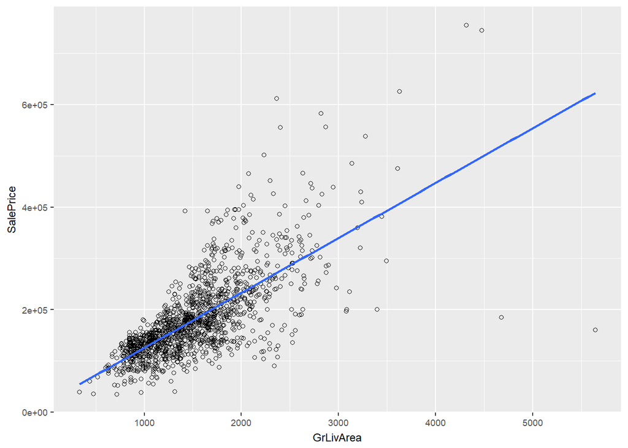

```r
p5 <-ggplot(train.dt, aes(GrLivArea,SalePrice)) +
        geom_point(shape=1) +      ## Use hollow circles
        geom_smooth(method=lm,     ## Add linear regression line
                    se=FALSE) +    ## Don't add shaded confidence region
        theme(text = element_text(size=9))
print(p5)
```

## 6.2 Scatterplot LotArea vs GrLivArea

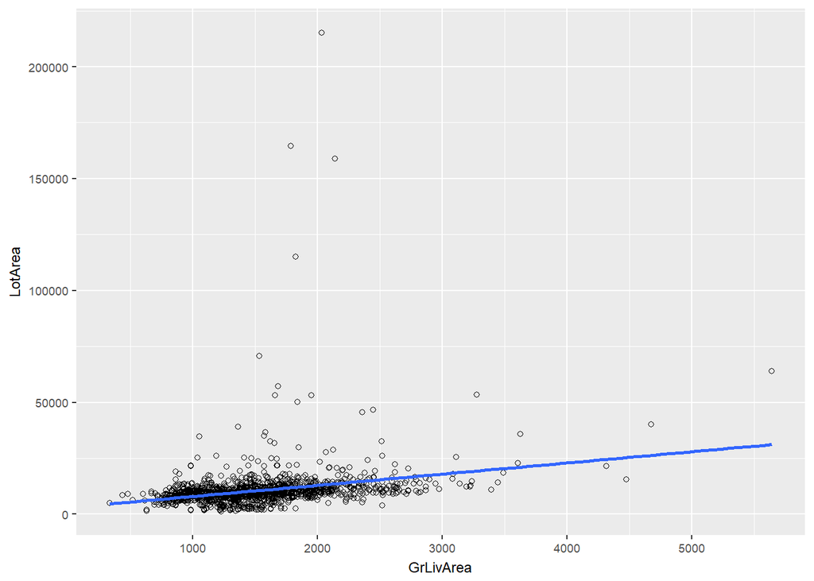

```r
p9 <-ggplot(train.dt, aes(GrLivArea,LotArea)) +
        geom_point(shape=1) +      ## Use hollow circles
        geom_smooth(method=lm,     ## Add linear regression line
                    se=FALSE) +    ## Don't add shaded confidence region
        theme(text = element_text(size=9))
print(p9)
```

## 6.3 Boxplot saleprice per neighborhood

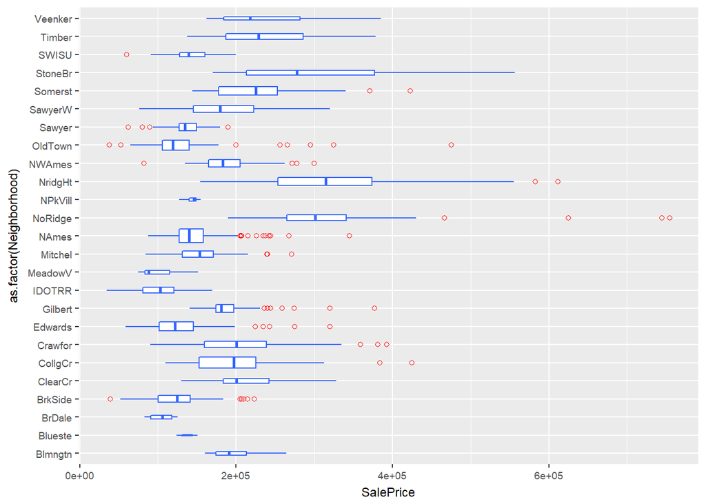

```r
p3a <-ggplot(train.dt, aes(as.factor(Neighborhood),SalePrice)) +
        geom_boxplot(varwidth = TRUE, fill = "white", colour = "#3366FF", outlier.colour = "red", outlier.shape = 1) +
        theme(text = element_text(size=9)) +
        coord_flip()
print(p3a)
```

## 6.4 Scatterplot saleprice per OverallQual

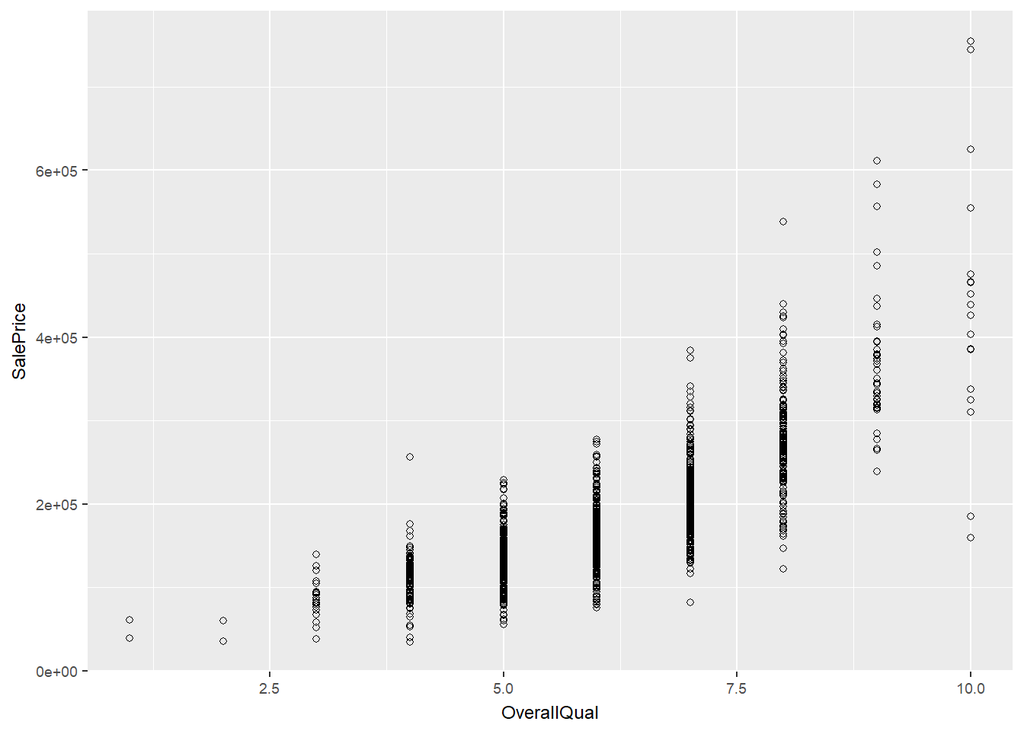

```r
p4 <-ggplot(train.dt, aes(OverallQual,SalePrice)) +
        geom_point(shape=1) +      ## Use hollow circles
        theme(text = element_text(size=9))
print(p4)
```